# Introduction to Statistical Learning - Chapter 10 - Deep Learning - Labs

Saad M. Siddiqui 2022-04-14

My attempt at translating Chapter 10's labs to Python because I don't want to go through the hassle of linking my R installation to my Python installation.

# Libraries

```python
import matplotlib.pyplot as plt
import numpy as np
import os
import pandas as pd

from sklearn.compose import ColumnTransformer
from sklearn.linear_model import LinearRegression, LassoCV, LogisticRegressionCV
from sklearn.model_selection import train_test_split
from sklearn.metrics import accuracy_score, mean_absolute_error, r2_score
from sklearn.pipeline import Pipeline
from sklearn.preprocessing import OneHotEncoder, StandardScaler

from tensorflow import keras
from tensorflow.keras.preprocessing.sequence import pad_sequences
from tensorflow.keras.utils import plot_model, to_categorical
from tensorflow.keras.datasets import mnist, cifar100, imdb
```

# Example 01 - A Single Layer Network on Hitters Data

First, I read in the `Hitters` data from a CSV I downloaded from [this link](https://gist.githubusercontent.com/keeganhines/59974f1ebef97bbaa44fb19143f90bad/raw/d9bcf657f97201394a59fffd801c44347eb7e28d/Hitters.csv).

```python
HITTERS_FILEPATH = f"{os.getcwd()}/hitters.csv"
hitters = pd.read_csv(HITTERS_FILEPATH)

# Drop the player name, because we ideally want to use integer index
hitters.drop(['Unnamed: 0'], axis = 1, inplace = True)
hitters.head()
```

|  | AtBat | Hits | HmRun | Runs | RBI | Walks | Years | CAtBat | CHits | CHmRun | CRuns | CRBI | CWalks | League | Division | PutOuts | Assists | Errors | Salary | NewLeague |
| --- | --- | --- | --- | --- | --- | --- | --- | --- | --- | --- | --- | --- | --- | --- | --- | --- | --- | --- | --- | --- |
| 0 | 293 | 66 | 1 | 30 | 29 | 14 | 1 | 293 | 66 | 1 | 30 | 29 | 14 | A | E | 446 | 33 | 20 | NaN | A |
| 1 | 315 | 81 | 7 | 24 | 38 | 39 | 14 | 3449 | 835 | 69 | 321 | 414 | 375 | N | W | 632 | 43 | 10 | 475.0 | N |
| 2 | 479 | 130 | 18 | 66 | 72 | 76 | 3 | 1624 | 457 | 63 | 224 | 266 | 263 | A | W | 880 | 82 | 14 | 480.0 | A |
| 3 | 496 | 141 | 20 | 65 | 78 | 37 | 11 | 5628 | 1575 | 225 | 828 | 838 | 354 | N | E | 200 | 11 | 3 | 500.0 | N |
| 4 | 321 | 87 | 10 | 39 | 42 | 30 | 2 | 396 | 101 | 12 | 48 | 46 | 33 | N | E | 805 | 40 | 4 | 91.5 | N |

Remove rows with missing values and store the filtered `DataFrame` as `Gitters`

```python
hitters.info()
```

```
<class 'pandas.core.frame.DataFrame'>
RangeIndex: 322 entries, 0 to 321
Data columns (total 20 columns):
AtBat        322 non-null int64
Hits         322 non-null int64
HmRun        322 non-null int64
Runs         322 non-null int64
RBI          322 non-null int64
Walks        322 non-null int64
Years        322 non-null int64
CAtBat       322 non-null int64
CHits        322 non-null int64
CHmRun       322 non-null int64
CRuns        322 non-null int64
CRBI         322 non-null int64
CWalks       322 non-null int64
League       322 non-null object
Division     322 non-null object
PutOuts      322 non-null int64
Assists      322 non-null int64
Errors       322 non-null int64
Salary       263 non-null float64
NewLeague    322 non-null object
dtypes: float64(1), int64(16), object(3)
memory usage: 50.4+ KB
```

```python
gitters = hitters[~hitters['Salary'].isnull()]
gitters.info()
```

```
<class 'pandas.core.frame.DataFrame'>
Int64Index: 263 entries, 1 to 321
Data columns (total 20 columns):
AtBat        263 non-null int64
Hits         263 non-null int64
HmRun        263 non-null int64
Runs         263 non-null int64
RBI          263 non-null int64
Walks        263 non-null int64
Years        263 non-null int64
CAtBat       263 non-null int64
CHits        263 non-null int64
CHmRun       263 non-null int64
CRuns        263 non-null int64
CRBI         263 non-null int64
CWalks       263 non-null int64
League       263 non-null object
Division     263 non-null object
PutOuts      263 non-null int64
Assists      263 non-null int64
Errors       263 non-null int64
Salary       263 non-null float64
NewLeague    263 non-null object
dtypes: float64(1), int64(16), object(3)
memory usage: 43.1+ KB
```

Identifying target, categorical features, and numeric features

```python
target = ['Salary']
gitters_X = gitters.drop(target, axis = 1)
gitters_y = gitters[target]

cat_attribs = gitters_X.columns[gitters_X.dtypes == 'object'].tolist()
num_attribs = gitters_X.columns[gitters_X.dtypes != 'object'].tolist()
```

Setting up train and test set indices

```python
n = gitters.shape[0]     # Number of rows
np.random.seed(13)       # Seed random number generator
n_test = n // 3          # Number of test set samples as an integer

# Use sklearn's train-test split API to get a separate training and test set
X_train, X_test, y_train, y_test = train_test_split(
    gitters_X, gitters_y, test_size = n_test
)

# Checking shapes
print("X_train: ", X_train.shape)
print("X_train: ", X_test.shape)
print("y_train: ", y_train.shape)
print("y_test: ", y_test.shape)
```

```
X_train:  (176, 19)
X_train:  (87, 19)
y_train:  (176, 1)
y_test:  (87, 1)
```

## Linear Model 01: OLS Regression

```python
# The only preprocessing we'll perform is one hot encoding or dummificaton of categorical features
gitters_lin_reg_preprocessor = ColumnTransformer(
    transformers = [
        ('cat_transformer', OneHotEncoder(), cat_attribs)
    ]
)

# We combine this column transformation step with a Linear Regression predictr
gitters_lin_reg_pipeline = Pipeline(
    steps = [
        ('preprocessor', gitters_lin_reg_preprocessor),
        ('regressor', LinearRegression())
    ]
)

# Train the model
gitters_lin_reg_pipeline.fit(X_train, y_train)

# Use it to make predictions and compute MAE
gitters_lin_reg_pred = gitters_lin_reg_pipeline.predict(X_test)
gitters_lin_reg_mae = mean_absolute_error(y_true = y_test, y_pred = gitters_lin_reg_pred)

print(f"MAE for OLS Linear Regression: {np.round(gitters_lin_reg_mae, 2)}")
```

```
MAE for OLS Linear Regression: 353.07
```

## Linear Model 02: Lasso Regression

For the lasso regression, we also want to standardize the numeric columns in addition to dummifying the categorical columns. This is best done with a `Pipeline` object in conjunction with a `ColumnTransformer` that combines a `OneHotEncoder` and a `StandardScaler`.

```python
# Instantiate a preprocessing transformer
gitters_lasso_reg_preprocessor = ColumnTransformer(
    transformers = [
        ('cat_transformer', OneHotEncoder(), cat_attribs),
        ('num_transformer', StandardScaler(), num_attribs)
    ]
)

# Combine with a regressor in the pipeline with a LassoCV regressor
# LassoCV regressor receives a pre-initialized list of alpha values (regularization strength)
alpha_grid = 10.0 ** np.arange(-5, 5, 1)
gitters_lasso_reg_pipeline = Pipeline(
    steps = [
        ('preprocessor', gitters_lasso_reg_preprocessor),
        ('cv_lasso_regressor', LassoCV(alphas = alpha_grid, verbose = 1))
    ]
)

# Fit to training data
gitters_lasso_reg_pipeline.fit(X_train, y_train)
```

```python
gitters_lasso_reg_pred = gitters_lasso_reg_pipeline.predict(X_test)
gitters_lasso_reg_mae = mean_absolute_error(y_true = y_test, y_pred = gitters_lasso_reg_pred)
print("Test MAE for cross-validated Lasso Regressor is:\t", np.round(gitters_lasso_reg_mae, 2))
```

```
Test MAE for cross-validated Lasso Regressor is:	 242.24
```

## Feedforward Neural Network

We first preprocess the features to make sure we have input tensors for the right dimensions and scale for both training and test data.

This is also important because we need to know the dimensions of the input data before we can instantiate the ANN.

```python
# Create a preprocessor for the neural network's features
gitters_ann_preprocessor = Pipeline([
    ('preprocessor', ColumnTransformer([
        ('one_hot_encoder', OneHotEncoder(), cat_attribs),
        ('standard_scaler', StandardScaler(), num_attribs)
    ]))
])

# Use the training data to learn the mean/SD for standardization of numeric features
# and the categories for encoding the categorical features
gitters_ann_X_train = gitters_ann_preprocessor.fit_transform(X_train, y_train)

# Having learnt these parameters, use them to modify the test set predictors
gitters_ann_X_test = gitters_ann_preprocessor.transform(X_test)

# Validate shape and values within the train and test set. First 6 columns are one-hot encoded
# Remainder are the numerics
print("*" * 100)
print("Validating Training Data")
print("Train shape: ", gitters_ann_X_train.shape)
print("Train means")
print(gitters_ann_X_train.mean(axis = 0))
print("Train SD")
print(gitters_ann_X_train.std(axis = 0))

print("*" * 100)
print("Validating Test Data")
print("Test shape: ", gitters_ann_X_test.shape)
print("Test means")
print(gitters_ann_X_test.mean(axis = 0))
print("Test SD")
print(gitters_ann_X_test.std(axis = 0))
```

[output not shown]

We now instantiate a feed forward neural network.

```python
gitters_ann_X_train.shape[1]
```

```
22
```

```python
gitters_ann = keras.models.Sequential([
    keras.layers.Input(shape = (gitters_ann_X_train.shape[1])),
    keras.layers.Dense(units = 50, activation = 'relu'),
    keras.layers.Dropout(rate = 0.4),
    keras.layers.Dense(units = 1)
])

# Display a table showing the names, I/O shapes and trainable parameter count for each layer
gitters_ann.summary()
```

```
Model: "sequential"
_________________________________________________________________
Layer (type)                 Output Shape              Param #
=================================================================
dense (Dense)                (None, 50)                1150
_________________________________________________________________
dropout (Dropout)            (None, 50)                0
_________________________________________________________________
dense_1 (Dense)              (None, 1)                 51
=================================================================
Total params: 1,201
Trainable params: 1,201
Non-trainable params: 0
_________________________________________________________________
```

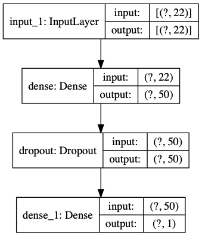

```python
# Same information displayed as a graph
plot_model(gitters_ann, show_shapes = True, show_layer_names = True)
```

We then compile the ANN model by specifying the following hyperparameters

- `loss`: which function to use to compute loss which, in turn, can be used as a signal for optimising weights
- `optimizer`: which variant of gradient descent to use for optimising the weights
- `metrics`: quantities to track during training/validation

```python
# Before we train the model, we need to compile it to specify hyperparameters
gitters_ann.compile(
    loss = 'mse', optimizer = 'RMSprop', metrics = ['mean_absolute_error']
)
```

We now fit the model while specifying some more hyperparameters

- `batch_size`: how many randomly sampled data points from the training set will be used for each step of gradient descent step.
- `epochs`: how many full passes through the training data need to be made during training
- `validation_data`: optional data to use for checking outsample performance with every epoch

I have removed the output from the `gitters_ann.fit` command to make the Notebook more readable.

```python
gitters_ann_history = gitters_ann.fit(
    x = gitters_ann_X_train, y = y_train, epochs = 1500,
    batch_size = 32, validation_data = [gitters_ann_X_test, y_test],
    verbose = 1
)
```

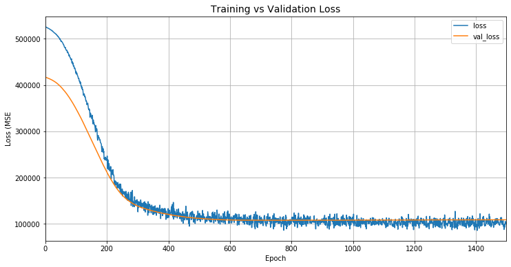

```python
# First display the training and validation loss
pd.DataFrame(gitters_ann_history.history)[['loss', 'val_loss']].plot(figsize = (12, 6))
plt.title("Training vs Validation Loss", size = 14);
plt.xlabel('Epoch'); plt.ylabel('Loss (MSE');
plt.grid(True);
```

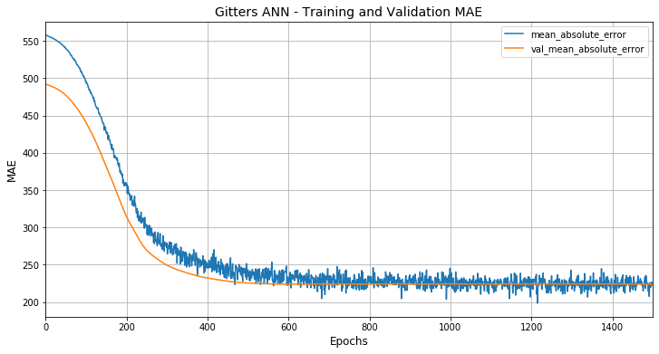

```python
# Repeat the same process for the mean absolute error
pd.DataFrame(gitters_ann_history.history)[['mean_absolute_error', 'val_mean_absolute_error']].plot(figsize = (12, 6));
plt.title("Gitters ANN - Training and Validation MAE", size = 14);
plt.xlabel('Epochs', size = 12);
plt.ylabel('MAE', size = 12);
plt.grid(True);
```

Both the MSE and MAE show the same trend: surprisingly, error is higher in the training data and less on the test data. This might be because the data points in the test set are "easier" than the ones in the training set. However, we expect to see the opposite in real world examples: training MSE/MAE will be lower than validation test.

We now use the neural network to predict on the test set and check its MA using the weights from the end of training.

```python
gitters_ann_pred = gitters_ann.predict(gitters_ann_X_test)
gitters_ann_mae = mean_absolute_error(y_true = y_test, y_pred = gitters_ann_pred)
print(f"Test Set MAE with FF ANN is {np.round(gitters_ann_mae, 2)}")
```

```
Test Set MAE with FF ANN is 223.84
```

To summarize, we show the mean absolute errors on the same test set for the all three methods.

```python
example_01_results = pd.DataFrame({
    'predictor': ['ols_reg', 'lasso_reg', 'ff_ann'],
    'test_mae': [gitters_lin_reg_mae, gitters_lasso_reg_mae, gitters_ann_mae]
})

example_01_results['test_mae'] = np.round(example_01_results['test_mae'])
example_01_results
```

|  | predictor | test_mae |
| --- | --- | --- |
| 0 | ols_reg | 353.0 |
| 1 | lasso_reg | 242.0 |
| 2 | ff_ann | 224.0 |

The feedforward neural network has the lowest test set MAE on this data set, followed by lasso regression and OLS linear regression.

This is a bit counterintuitive because the lasso regressor is the most regularized, while the feedforward neural network has the highest propensity to overfit.